# 571121

[github link for Jupyter Notebook](https://github.com/sureshdpawar/gen-ai-ut-project6-support-ticket/blob/main/NLP_Project_Low_Code_Suresh_Pawar.ipynb)

## **Problem Statement**

### Business Context

In today's dynamic business landscape, organizations are increasingly recognizing the pivotal role customer feedback plays in shaping the trajectory of their products and services. The ability to swiftly and effectively respond to customer input not only fosters enhanced customer experiences but also serves as a catalyst for growth, prolonged customer engagement, and the nurturing of lifetime value relationships. As a dedicated Product Manager or Product Analyst, staying attuned to the voice of your customers is not just a best practice; it's a strategic imperative.

While your organization may be inundated with a wealth of customer-generated feedback and support tickets, your role entails much more than just processing these inputs. To make your efforts in managing customer experience and expectations truly impactful, you need a structured approach – a method that allows you to discern the most pressing issues, set priorities, and allocate resources judiciously. One of the most effective strategies at your disposal is to harness the power of Support Ticket Categorization.

### Objective

Develop an advanced support ticket categorization system that accurately classifies incoming tickets, assigns relevant tags based on their content, implements mechanisms and generate the first response based on the sentiment for prioritizing tickets for prompt resolution.

## **Sample of Expected Output**

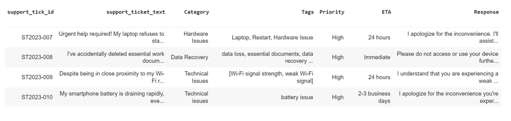

## **Please read the instructions carefully before starting the project.**

This is a commented Python Notebook file in which all the instructions and tasks to be performed are mentioned.

- Blanks '_______' are provided in the notebook that needs to be filled with an appropriate code to get the correct result. With every '_______' blank, there is a comment that briefly describes what needs to be filled in the blank space.
- Identify the task to be performed correctly, and only then proceed to write the required code.
- Please run the codes in a sequential manner from the beginning to avoid any unnecessary errors.
- Add the results/observations (wherever mentioned) derived from the analysis in the presentation and submit the same. Any mathematical or computational details which are a graded part of the project can be included in the Appendix section of the presentation.

**Note**: If the free-tier GPU of Google Colab is not accessible (due to unavailability or exhaustion of daily limit or other reasons), the following steps can be taken:

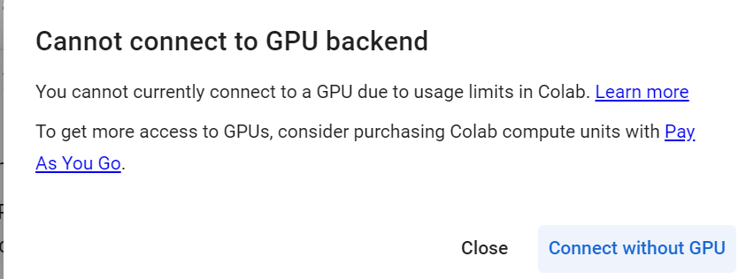

## **Installing and Importing Necessary Libraries and Dependencies**

```python
# Installation for GPU llama-cpp-python
# uncomment and run the following code in case GPU is being used

!CMAKE_ARGS="-DLLAMA_CUBLAS=on" FORCE_CMAKE=1 pip install llama-cpp-python==0.2.45 --force-reinstall --no-cache-dir -q
```

[output not shown]

```python
# Installation for CPU llama-cpp-python
# uncomment and run the following code in case GPU is not being used

# !CMAKE_ARGS="-DLLAMA_CUBLAS=off" FORCE_CMAKE=1 pip install llama-cpp-python==0.2.45 --force-reinstall --no-cache-dir -q
```

**Note** : There may be an error related to a dependency issue thrown by the pip package. This can be ignored as it will not impact the execution of the code.

```python
# For downloading the models from HF Hub
!pip install huggingface_hub==0.20.3 pandas==1.5.3 -q
```

[output not shown]

```python
# Function to download the model from the Hugging Face model hub
from huggingface_hub import hf_hub_download

# Importing the Llama class from the llama_cpp module
from llama_cpp import Llama

# Importing the json module
import json

# for loading and manipulating data
import pandas as pd

# for time computations
import time
```

## **Loading the Data**

```python
from google.colab import drive
drive.mount('/content/drive')
%cd /content/drive/MyDrive/AI-ML
```

```
/content/drive/MyDrive/AI-ML
```

```python
# Complete the code to read the CSV file.
data = pd.read_csv("Support_ticket_text_data_mid_term.csv")
```

## **Data Overview**

### Checking the first 5 rows of the data

```python
# Complete the code to check the first 5 rows of the data
data.head(5)
```

|  | support_tick_id | support_ticket_text |
| --- | --- | --- |
| 0 | ST2023-006 | My internet connection has significantly slowe... |
| 1 | ST2023-007 | Urgent help required! My laptop refuses to sta... |
| 2 | ST2023-008 | I've accidentally deleted essential work docum... |
| 3 | ST2023-009 | Despite being in close proximity to my Wi-Fi r... |
| 4 | ST2023-010 | My smartphone battery is draining rapidly, eve... |

### Checking the shape of the data

```python
# Complete the code to check the shape of the data
data.shape
```

```
(21, 2)
```

### Checking the missing values in the data

```python
# Complete the code to check for missing values in the data
data.isnull().sum()
```

```
support_tick_id        0
support_ticket_text    0
dtype: int64
```

```python
# checking for duplicate values
data.duplicated().sum()
```

```
0
```

### Observations:

There are 21 records and two columns in a dataset, no null values and duplicate values.

## **Model Building**

### Loading the model

```python
model_name_or_path = "TheBloke/Mistral-7B-Instruct-v0.2-GGUF"
model_basename = "mistral-7b-instruct-v0.2.Q6_K.gguf"
```

```python
model_path = hf_hub_download(
    repo_id=model_name_or_path, # Complete the code to mention the repo_id
    filename=model_basename  # Complete the code to mention the filename
)
```

```json
{"model_id":"23ebbc15ddb94272a6ea1079583057be","version_major":2,"version_minor":0}
```

```python
# uncomment and run the following code in case GPU is being used

llm = Llama(
  model_path=model_path,
  n_ctx=1024, # Context window
 )
```

[output not shown]

[output cut: 30 more lines]

[output not shown]

```python
# uncomment and run the following code in case GPU is not being used

# llm = Llama(
#     model_path=model_path,
#     n_ctx=1024, # Context window
#     n_cores=-2 # Number of CPU cores to use
# )
```

### Utility functions

```python
# defining a function to parse the JSON output from the model
def extract_json_data(json_str):
    try:
        # Find the indices of the opening and closing curly braces
        json_start = json_str.find('{')
        json_end = json_str.rfind('}')

        if json_start != -1 and json_end != -1:
            extracted_category = json_str[json_start:json_end + 1]  # Extract the JSON object
            data_dict = json.loads(extracted_category)
            return data_dict
        else:
            print(f"Warning: JSON object not found in response: {json_str}")
            return {}
    except json.JSONDecodeError as e:
        print(f"Error parsing JSON: {e}")
        return {}
```

## **Task 1: Ticket Categorization and Returning Structured Output**

```python
# creating a copy of the data
data_1 = data.copy()
```

```python
#Defining the response funciton for Task 1.
def response_1(prompt,ticket):
    model_output = llm(
      f"""
      Q: {prompt}
      Support ticket: {ticket}
      A:
      """,
      max_tokens=1024, #Complete the code to set the maximum number of tokens the model should generate for this task.
      stop=["Q:", "\n"],
      temperature=0.01, #Complete the code to set the value for temperature.
      echo=False,
    )

    temp_output = model_output["choices"][0]["text"]
    final_output = temp_output[temp_output.index('{'):]

    return final_output
```

```python
prompt_1 = """
Given a support ticket text, categorize it into one of the following predefined categories:
  1. Data Recovery
  2. Technical Issues
  3. Hardware Issues
  4. Other

  Format the output as a JSON object with a single key-value pair as shown below:
   {"Category": "your_label_prediction"}
"""
```

**Note**: The output of the model should be in a structured format (JSON format).

```python
start = time.time()
data_1['model_response'] = data_1['support_ticket_text'].apply(lambda x: response_1(prompt_1, x))
end = time.time()
```

[output not shown]

[output cut: 90 more lines]

[output not shown]

```python
print("Time taken ",(end-start))
```

```
Time taken  300.1082000732422
```

```python
# Write the code to check the first five rows of the data to confirm whether the new column has been added
data_1.head(5)
```

|  | support_tick_id | support_ticket_text | model_response |
| --- | --- | --- | --- |
| 0 | ST2023-006 | My internet connection has significantly slowe... | {"Category": "Technical Issues"} |
| 1 | ST2023-007 | Urgent help required! My laptop refuses to sta... | {"Category": "Hardware Issues"} |
| 2 | ST2023-008 | I've accidentally deleted essential work docum... | {"Category": "Data Recovery"} |
| 3 | ST2023-009 | Despite being in close proximity to my Wi-Fi r... | {"Category": "Technical Issues"} |
| 4 | ST2023-010 | My smartphone battery is draining rapidly, eve... | {"Category": "Hardware Issues"} |

```python
i = 2
print(data_1.loc[i, 'support_ticket_text'])
```

```
I've accidentally deleted essential work documents, causing substantial data loss. I understand the need to avoid further actions on my device. Can you please prioritize the data recovery process and guide me through it?
```

```python
print(data_1.loc[i, 'model_response'])
```

```
{"Category": "Data Recovery"}
```

```python
# applying the function to the model response
data_1['model_response_parsed'] = data_1['model_response'].apply(extract_json_data)
data_1['model_response_parsed'].head()
```

```
0    {'Category': 'Technical Issues'}
1     {'Category': 'Hardware Issues'}
2       {'Category': 'Data Recovery'}
3    {'Category': 'Technical Issues'}
4     {'Category': 'Hardware Issues'}
Name: model_response_parsed, dtype: object
```

```python
data_1['model_response_parsed'].value_counts()
```

```
{'Category': 'Technical Issues'}                   7
{'Category': 'Data Recovery'}                      7
{'Category': 'Hardware Issues'}                    6
{'Category': 'Technical Issues, Data Recovery'}    1
Name: model_response_parsed, dtype: int64
```

```python
# Normalizing the model_response_parsed column
model_response_parsed_df_1 = pd.json_normalize(data_1['model_response_parsed'])
model_response_parsed_df_1.head()
```

|  | Category |
| --- | --- |
| 0 | Technical Issues |
| 1 | Hardware Issues |
| 2 | Data Recovery |
| 3 | Technical Issues |
| 4 | Hardware Issues |

```python
# Concatinating two dataframes
data_with_parsed_model_output_1 = pd.concat([data_1, model_response_parsed_df_1], axis=1)
data_with_parsed_model_output_1.head()
```

|  | support_tick_id | support_ticket_text | model_response | model_response_parsed | Category |
| --- | --- | --- | --- | --- | --- |
| 0 | ST2023-006 | My internet connection has significantly slowe... | {"Category": "Technical Issues"} | {'Category': 'Technical Issues'} | Technical Issues |
| 1 | ST2023-007 | Urgent help required! My laptop refuses to sta... | {"Category": "Hardware Issues"} | {'Category': 'Hardware Issues'} | Hardware Issues |
| 2 | ST2023-008 | I've accidentally deleted essential work docum... | {"Category": "Data Recovery"} | {'Category': 'Data Recovery'} | Data Recovery |
| 3 | ST2023-009 | Despite being in close proximity to my Wi-Fi r... | {"Category": "Technical Issues"} | {'Category': 'Technical Issues'} | Technical Issues |
| 4 | ST2023-010 | My smartphone battery is draining rapidly, eve... | {"Category": "Hardware Issues"} | {'Category': 'Hardware Issues'} | Hardware Issues |

```python
# Dropping model_response and model_response_parsed columns
final_data_1 = data_with_parsed_model_output_1.drop(['model_response','model_response_parsed'], axis=1)
final_data_1.head()
```

|  | support_tick_id | support_ticket_text | Category |
| --- | --- | --- | --- |
| 0 | ST2023-006 | My internet connection has significantly slowe... | Technical Issues |
| 1 | ST2023-007 | Urgent help required! My laptop refuses to sta... | Hardware Issues |
| 2 | ST2023-008 | I've accidentally deleted essential work docum... | Data Recovery |
| 3 | ST2023-009 | Despite being in close proximity to my Wi-Fi r... | Technical Issues |
| 4 | ST2023-010 | My smartphone battery is draining rapidly, eve... | Hardware Issues |

## **Task 2: Creating Tags**

```python
# creating a copy of the data
data_2 = data.copy()
```

```python
def response_2(prompt,ticket,category):
    model_output = llm(
      f"""
      Q: {prompt}
      Support ticket: {ticket}
      Category: {category}
      A:
      """,
      max_tokens=1024, #Complete the code to set the maximum number of tokens the model should generate for this task.
      stop=["Q:", "\n"],
      temperature=0.01, #Complete the code to set the value for temperature.
      echo=False,
    )

    temp_output = model_output["choices"][0]["text"]
    print(temp_output)  # Print the model output
    final_output = temp_output[temp_output.index('{'):]

    return final_output
```

```python
prompt_2 = """
  Generate relevant tags for support tickets based on their text content and category. The dataset contains support ticket texts and corresponding categories. Each row consists of a support ticket text and a category. Please use the provided data to prompt the model to extract relevant tags that describe the problem for each support ticket.

  Format the output as a JSON object with a single key-value pair as shown below:
  {"Tags": "extracted_tags"}
"""
```

**Note**: The output of the model should be in a structured format (JSON format).

```python
start = time.time()
data_2["model_response"]=final_data_1[['support_ticket_text','Category']].apply(lambda x: response_2(prompt_2, x[0],x[1]),axis =1)
end = time.time()
```

[output not shown]

```
 {"Tags": ["Internet Connection", "Slow Internet", "Disconnections", "Home Network"]}
```

[output not shown]

```
 {"Tags": ["laptop", "startup issue", "hardware failure", "presentation", "urgent"]}
```

[output not shown]

```
 {"Tags": ["Data Loss", "Document Recovery", "Data Recovery Process"]}
```

[output not shown]

```
 {"Tags": ["Wi-Fi signal", "Weak signal", "Troubleshooting", "Technical Issues"]}
```

[output not shown]

```
 {"Tags": ["Battery Drain", "Smartphone", "Hardware"]}
```

[output not shown]

```
 {"Tags": ["Account Access", "Password Reset", "Online Banking", "Urgent"]}
```

[output not shown]

```
 {"Tags": ["Performance issues", "Computer optimization", "Productivity", "Technical support"]}
```

[output not shown]

```
 {"Tags": ["Blue Screen Error", "Hardware Issue", "Crash", "PC"]}
```

[output not shown]

```
 {"Tags": ["External Hard Drive", "Data Recovery", "Not Recognized", "Vital Data"]}
```

[output not shown]

```
 {"Tags": ["Graphics Card Malfunction", "Gaming Performance Issues", "Hardware Diagnosis"]}
```

[output not shown]

```
 {"Tags": ["USB drive", "Data loss", "Data recovery", "File recovery"]}
```

[output not shown]

```
 {"Tags": ["Screen issue", "Black screen", "Hardware malfunction", "Urgent"]}
```

[output not shown]

```
 {"Tags": ["Water Damage", "Laptop", "Data Recovery"]}
```

[output not shown]

```
 {"Tags": ["Physical Damage", "Data Recovery", "USB Flash Drive"]}
```

[output not shown]

```
 {"Tags": ["touchpad", "laptop", "hardware", "issue", "troubleshoot"]}
```

[output not shown]

```
 {"Tags": ["Internet Connection", "Dropouts", "Technical Issue", "Urgent"]}
```

[output not shown]

```
 {"Tags": ["Wi-Fi", "Connectivity", "Router", "Inconsistent", "Work"]}
```

[output not shown]

```
 {"Tags": ["accidental_format", "data_recovery"]}
```

[output not shown]

```
 {"Tags": ["External Hard Drive", "Data Recovery", "Not Recognized"]}
```

[output not shown]

```
 {"Tags": ["Internet Connection", "Slow Speed", "Disconnections", "Productivity Loss", "Urgent", "Technical Support"]}
```

[output not shown]

```
 {"Tags": ["Software issues", "Unusual behavior", "Crashing applications", "Data loss", "File disappearance", "System issues", "Technical assistance", "Remote diagnostics"]}
```

```python
print("Time taken ",end-start)
```

```
Time taken  487.8774745464325
```

```python
# Write the code to check the first five rows of the data to confirm whether the new column has been added
data_2.head(5)
```

|  | support_tick_id | support_ticket_text | model_response |
| --- | --- | --- | --- |
| 0 | ST2023-006 | My internet connection has significantly slowe... | {"Tags": ["Internet Connection", "Slow Interne... |
| 1 | ST2023-007 | Urgent help required! My laptop refuses to sta... | {"Tags": ["laptop", "startup issue", "hardware... |
| 2 | ST2023-008 | I've accidentally deleted essential work docum... | {"Tags": ["Data Loss", "Document Recovery", "D... |
| 3 | ST2023-009 | Despite being in close proximity to my Wi-Fi r... | {"Tags": ["Wi-Fi signal", "Weak signal", "Trou... |
| 4 | ST2023-010 | My smartphone battery is draining rapidly, eve... | {"Tags": ["Battery Drain", "Smartphone", "Hard... |

```python
i = 2
print(data_2.loc[i, 'support_ticket_text'])
```

```
I've accidentally deleted essential work documents, causing substantial data loss. I understand the need to avoid further actions on my device. Can you please prioritize the data recovery process and guide me through it?
```

```python
print(data_2.loc[i, 'model_response'])
```

```
{"Tags": ["Data Loss", "Document Recovery", "Data Recovery Process"]}
```

```python
# Applying the function to the model response
data_2['model_response_parsed'] = data_2['model_response'].apply(extract_json_data)
```

```python
data_2["model_response_parsed"]
```

```
0     {'Tags': ['Internet Connection', 'Slow Interne...
1     {'Tags': ['laptop', 'startup issue', 'hardware...
2     {'Tags': ['Data Loss', 'Document Recovery', 'D...
3     {'Tags': ['Wi-Fi signal', 'Weak signal', 'Trou...
4     {'Tags': ['Battery Drain', 'Smartphone', 'Hard...
5     {'Tags': ['Account Access', 'Password Reset', ...
6     {'Tags': ['Performance issues', 'Computer opti...
7     {'Tags': ['Blue Screen Error', 'Hardware Issue...
8     {'Tags': ['External Hard Drive', 'Data Recover...
9     {'Tags': ['Graphics Card Malfunction', 'Gaming...
10    {'Tags': ['USB drive', 'Data loss', 'Data reco...
11    {'Tags': ['Screen issue', 'Black screen', 'Har...
12    {'Tags': ['Water Damage', 'Laptop', 'Data Reco...
13    {'Tags': ['Physical Damage', 'Data Recovery', ...
14    {'Tags': ['touchpad', 'laptop', 'hardware', 'i...
15    {'Tags': ['Internet Connection', 'Dropouts', '...
16    {'Tags': ['Wi-Fi', 'Connectivity', 'Router', '...
17     {'Tags': ['accidental_format', 'data_recovery']}
18    {'Tags': ['External Hard Drive', 'Data Recover...
19    {'Tags': ['Internet Connection', 'Slow Speed',...
20    {'Tags': ['Software issues', 'Unusual behavior...
Name: model_response_parsed, dtype: object
```

```python
# Normalizing the model_response_parsed column
model_response_parsed_df_2 = pd.json_normalize(data_2['model_response_parsed'])
model_response_parsed_df_2.head()
```

|  | Tags |
| --- | --- |
| 0 | [Internet Connection, Slow Internet, Disconnec... |
| 1 | [laptop, startup issue, hardware failure, pres... |
| 2 | [Data Loss, Document Recovery, Data Recovery P... |
| 3 | [Wi-Fi signal, Weak signal, Troubleshooting, T... |
| 4 | [Battery Drain, Smartphone, Hardware] |

```python
# Concatinating two dataframes
data_with_parsed_model_output_2 = pd.concat([data_2, model_response_parsed_df_2], axis=1)
data_with_parsed_model_output_2.head()
```

|  | support_tick_id | support_ticket_text | model_response | model_response_parsed | Tags |
| --- | --- | --- | --- | --- | --- |
| 0 | ST2023-006 | My internet connection has significantly slowe... | {"Tags": ["Internet Connection", "Slow Interne... | {'Tags': ['Internet Connection', 'Slow Interne... | [Internet Connection, Slow Internet, Disconnec... |
| 1 | ST2023-007 | Urgent help required! My laptop refuses to sta... | {"Tags": ["laptop", "startup issue", "hardware... | {'Tags': ['laptop', 'startup issue', 'hardware... | [laptop, startup issue, hardware failure, pres... |
| 2 | ST2023-008 | I've accidentally deleted essential work docum... | {"Tags": ["Data Loss", "Document Recovery", "D... | {'Tags': ['Data Loss', 'Document Recovery', 'D... | [Data Loss, Document Recovery, Data Recovery P... |
| 3 | ST2023-009 | Despite being in close proximity to my Wi-Fi r... | {"Tags": ["Wi-Fi signal", "Weak signal", "Trou... | {'Tags': ['Wi-Fi signal', 'Weak signal', 'Trou... | [Wi-Fi signal, Weak signal, Troubleshooting, T... |
| 4 | ST2023-010 | My smartphone battery is draining rapidly, eve... | {"Tags": ["Battery Drain", "Smartphone", "Hard... | {'Tags': ['Battery Drain', 'Smartphone', 'Hard... | [Battery Drain, Smartphone, Hardware] |

```python
# Dropping model_response and model_response_parsed columns
final_data_2 = data_with_parsed_model_output_2.drop(['model_response','model_response_parsed'], axis=1)
final_data_2.head()
```

|  | support_tick_id | support_ticket_text | Tags |
| --- | --- | --- | --- |
| 0 | ST2023-006 | My internet connection has significantly slowe... | [Internet Connection, Slow Internet, Disconnec... |
| 1 | ST2023-007 | Urgent help required! My laptop refuses to sta... | [laptop, startup issue, hardware failure, pres... |
| 2 | ST2023-008 | I've accidentally deleted essential work docum... | [Data Loss, Document Recovery, Data Recovery P... |
| 3 | ST2023-009 | Despite being in close proximity to my Wi-Fi r... | [Wi-Fi signal, Weak signal, Troubleshooting, T... |
| 4 | ST2023-010 | My smartphone battery is draining rapidly, eve... | [Battery Drain, Smartphone, Hardware] |

```python
# Checking the value counts of Category column
final_data_2['Tags'].value_counts()
```

```
[Internet Connection, Slow Internet, Disconnections, Home Network]                                                                                    1
[laptop, startup issue, hardware failure, presentation, urgent]                                                                                       1
[Data Loss, Document Recovery, Data Recovery Process]                                                                                                 1
[Wi-Fi signal, Weak signal, Troubleshooting, Technical Issues]                                                                                        1
[Battery Drain, Smartphone, Hardware]                                                                                                                 1
[Account Access, Password Reset, Online Banking, Urgent]                                                                                              1
[Performance issues, Computer optimization, Productivity, Technical support]                                                                          1
[Blue Screen Error, Hardware Issue, Crash, PC]                                                                                                        1
[External Hard Drive, Data Recovery, Not Recognized, Vital Data]                                                                                      1
[Graphics Card Malfunction, Gaming Performance Issues, Hardware Diagnosis]                                                                            1
[USB drive, Data loss, Data recovery, File recovery]                                                                                                  1
[Screen issue, Black screen, Hardware malfunction, Urgent]                                                                                            1
[Water Damage, Laptop, Data Recovery]                                                                                                                 1
[Physical Damage, Data Recovery, USB Flash Drive]                                                                                                     1
[touchpad, laptop, hardware, issue, troubleshoot]                                                                                                     1
[Internet Connection, Dropouts, Technical Issue, Urgent]                                                                                              1
[Wi-Fi, Connectivity, Router, Inconsistent, Work]                                                                                                     1
[accidental_format, data_recovery]                                                                                                                    1
[External Hard Drive, Data Recovery, Not Recognized]                                                                                                  1
[Internet Connection, Slow Speed, Disconnections, Productivity Loss, Urgent, Technical Support]                                                       1
[Software issues, Unusual behavior, Crashing applications, Data loss, File disappearance, System issues, Technical assistance, Remote diagnostics]    1
Name: Tags, dtype: int64
```

```python
final_data_2 = pd.concat([final_data_2,final_data_1["Category"]],axis=1)
```

```python
final_data_2 = final_data_2[["support_tick_id","support_ticket_text","Category","Tags"]]
final_data_2
```

|  | support_tick_id | support_ticket_text | Category | Tags |
| --- | --- | --- | --- | --- |
| 0 | ST2023-006 | My internet connection has significantly slowe... | Technical Issues | [Internet Connection, Slow Internet, Disconnec... |
| 1 | ST2023-007 | Urgent help required! My laptop refuses to sta... | Hardware Issues | [laptop, startup issue, hardware failure, pres... |
| 2 | ST2023-008 | I've accidentally deleted essential work docum... | Data Recovery | [Data Loss, Document Recovery, Data Recovery P... |
| 3 | ST2023-009 | Despite being in close proximity to my Wi-Fi r... | Technical Issues | [Wi-Fi signal, Weak signal, Troubleshooting, T... |
| 4 | ST2023-010 | My smartphone battery is draining rapidly, eve... | Hardware Issues | [Battery Drain, Smartphone, Hardware] |
| 5 | ST2023-011 | I'm locked out of my online banking account an... | Technical Issues | [Account Access, Password Reset, Online Bankin... |
| 6 | ST2023-012 | My computer's performance is sluggish, severel... | Technical Issues | [Performance issues, Computer optimization, Pr... |
| 7 | ST2023-013 | I'm experiencing a recurring blue screen error... | Hardware Issues | [Blue Screen Error, Hardware Issue, Crash, PC] |
| 8 | ST2023-014 | My external hard drive isn't being recognized ... | Data Recovery | [External Hard Drive, Data Recovery, Not Recog... |
| 9 | ST2023-015 | The graphics card in my gaming laptop seems to... | Hardware Issues | [Graphics Card Malfunction, Gaming Performance... |
| 10 | ST2023-016 | I accidentally formatted my USB drive with cri... | Data Recovery | [USB drive, Data loss, Data recovery, File rec... |
| 11 | ST2023-017 | My computer's screen has gone black, and I can... | Hardware Issues | [Screen issue, Black screen, Hardware malfunct... |
| 12 | ST2023-018 | I accidentally spilled water on my laptop, and... | Data Recovery | [Water Damage, Laptop, Data Recovery] |
| 13 | ST2023-019 | My USB flash drive is physically damaged, and ... | Data Recovery | [Physical Damage, Data Recovery, USB Flash Drive] |
| 14 | ST2023-020 | The touchpad on my laptop has stopped working,... | Hardware Issues | [touchpad, laptop, hardware, issue, troubleshoot] |
| 15 | ST2023-021 | My internet connection is frequently dropping,... | Technical Issues | [Internet Connection, Dropouts, Technical Issu... |
| 16 | ST2023-022 | Wi-Fi is inconsistent despite proximity to the... | Technical Issues | [Wi-Fi, Connectivity, Router, Inconsistent, Work] |
| 17 | ST2023-023 | I accidentally formatted my USB drive with cru... | Data Recovery | [accidental_format, data_recovery] |
| 18 | ST2023-024 | My external hard drive isn't being recognized,... | Data Recovery | [External Hard Drive, Data Recovery, Not Recog... |
| 19 | ST2023-025 | I am experiencing a critical problem with my i... | Technical Issues | [Internet Connection, Slow Speed, Disconnectio... |
| 20 | ST2023-026 | I hope this message finds you well. I am writi... | Technical Issues, Data Recovery | [Software issues, Unusual behavior, Crashing a... |

## **Task 3: Assigning Priority and ETA**

```python
# creating a copy of the data
data_3 = data.copy()
```

```python
def response_3(prompt,ticket,category,tags):
    model_output = llm(
      f"""
      Q: {prompt}
      Support ticket: {ticket}
      Category: {category}
      Tags: {tags}
      A:
      """,
      max_tokens=1024,  #Complete the code to set the maximum number of tokens the model should generate for this task.
      stop=["Q:", "\n"],
      temperature=0.01, #Complete the code to set the value for temperature.
      echo=False,
    )

    temp_output = model_output["choices"][0]["text"]
    print(temp_output)
    final_output = temp_output[temp_output.index('{'):]

    return final_output
```

```python
prompt_3 = """
  Generate relevant Priority for support tickets based on their text content and category and tags. The dataset contains support ticket texts, corresponding categories and tags. Each row consists of a support ticket text, category and tags. Please use the provided data to prompt the model to give Priority for each support ticket.

  Format the output as a JSON object with a single key-value pair as shown below:
  {"Priority": "priority"}
"""
```

**Note**: The output of the model should be in a structured format (JSON format).

```python
# Applying generate_llama_response function on support_ticket_text column
start = time.time()
data_3['model_response'] = final_data_2[['support_ticket_text','Category','Tags']].apply(lambda x: response_3(prompt_3, x[0],x[1],x[2]),axis=1)
end = time.time()
```

[output not shown]

```
 {"Priority": "High"}
```

[output not shown]

```
 {"Priority": "High"}
```

[output not shown]

```
 {"Priority": "High"}
```

[output not shown]

```
 {"Priority": "High"}
```

[output not shown]

```
 {"Priority": "High"}
```

[output not shown]

```
 {"Priority": "High"}
```

[output not shown]

```
 {"Priority": "High"}
```

[output not shown]

```
 {"Priority": "High"}
```

[output not shown]

```
 {"Priority": "High"}
```

[output not shown]

```
 {"Priority": "High"}
```

[output not shown]

```
 {"Priority": "High"}
```

[output not shown]

```
 {"Priority": "High"}
```

[output not shown]

```
 {"Priority": "High"}
```

[output not shown]

```
 {"Priority": "High"}
```

[output not shown]

```
 {"Priority": "High"}
```

[output not shown]

```
 {"Priority": "High"}
```

[output not shown]

```
 {"Priority": "High"}
```

[output not shown]

```
 {"Priority": "High"}
```

[output not shown]

```
 {"Priority": "High"}
```

[output not shown]

```
 {"Priority": "High"}
```

[output not shown]

```
 {"Priority": "High"}
```

```python
print("Time taken ",(end-start))
```

```
Time taken  146.82982754707336
```

```python
# Write the code to check the first five rows of the data to confirm whether the new column has been added
data_3.head(5)
```

|  | support_tick_id | support_ticket_text | model_response |
| --- | --- | --- | --- |
| 0 | ST2023-006 | My internet connection has significantly slowe... | {"Priority": "High"} |
| 1 | ST2023-007 | Urgent help required! My laptop refuses to sta... | {"Priority": "High"} |
| 2 | ST2023-008 | I've accidentally deleted essential work docum... | {"Priority": "High"} |
| 3 | ST2023-009 | Despite being in close proximity to my Wi-Fi r... | {"Priority": "High"} |
| 4 | ST2023-010 | My smartphone battery is draining rapidly, eve... | {"Priority": "High"} |

```python
i = 2
print(data_3.loc[i, 'support_ticket_text'])
```

```
I've accidentally deleted essential work documents, causing substantial data loss. I understand the need to avoid further actions on my device. Can you please prioritize the data recovery process and guide me through it?
```

```python
print(data_3.loc[i, 'model_response'])
```

```
{"Priority": "High"}
```

```python
# Applying the function to the model response
data_3['model_response_parsed'] = data_3['model_response'].apply(extract_json_data)
data_3['model_response_parsed'].head()
```

```
0    {'Priority': 'High'}
1    {'Priority': 'High'}
2    {'Priority': 'High'}
3    {'Priority': 'High'}
4    {'Priority': 'High'}
Name: model_response_parsed, dtype: object
```

```python
# Normalizing the model_response_parsed column
model_response_parsed_df_3 = pd.json_normalize(data_3['model_response_parsed'])
model_response_parsed_df_3.head(21)
```

|  | Priority |
| --- | --- |
| 0 | High |
| 1 | High |
| 2 | High |
| 3 | High |
| 4 | High |
| 5 | High |
| 6 | High |
| 7 | High |
| 8 | High |
| 9 | High |
| 10 | High |
| 11 | High |
| 12 | High |
| 13 | High |
| 14 | High |
| 15 | High |
| 16 | High |
| 17 | High |
| 18 | High |
| 19 | High |
| 20 | High |

```python
# Concatinating two dataframes
data_with_parsed_model_output_3 = pd.concat([data_3, model_response_parsed_df_3], axis=1)
data_with_parsed_model_output_3.head()
```

|  | support_tick_id | support_ticket_text | model_response | model_response_parsed | Priority |
| --- | --- | --- | --- | --- | --- |
| 0 | ST2023-006 | My internet connection has significantly slowe... | {"Priority": "High"} | {'Priority': 'High'} | High |
| 1 | ST2023-007 | Urgent help required! My laptop refuses to sta... | {"Priority": "High"} | {'Priority': 'High'} | High |
| 2 | ST2023-008 | I've accidentally deleted essential work docum... | {"Priority": "High"} | {'Priority': 'High'} | High |
| 3 | ST2023-009 | Despite being in close proximity to my Wi-Fi r... | {"Priority": "High"} | {'Priority': 'High'} | High |
| 4 | ST2023-010 | My smartphone battery is draining rapidly, eve... | {"Priority": "High"} | {'Priority': 'High'} | High |

```python
# Dropping model_response and model_response_parsed columns
final_data_3 = data_with_parsed_model_output_3.drop(['model_response','model_response_parsed'], axis=1)
final_data_3.head()
```

|  | support_tick_id | support_ticket_text | Priority |
| --- | --- | --- | --- |
| 0 | ST2023-006 | My internet connection has significantly slowe... | High |
| 1 | ST2023-007 | Urgent help required! My laptop refuses to sta... | High |
| 2 | ST2023-008 | I've accidentally deleted essential work docum... | High |
| 3 | ST2023-009 | Despite being in close proximity to my Wi-Fi r... | High |
| 4 | ST2023-010 | My smartphone battery is draining rapidly, eve... | High |

```python
final_data_3 = pd.concat([final_data_3,final_data_2[["Category","Tags"]]],axis=1)
```

```python
final_data_3 = final_data_3[["support_tick_id","support_ticket_text","Category","Tags","Priority"]]
```

```python
final_data_3
```

|  | support_tick_id | support_ticket_text | Category | Tags | Priority |
| --- | --- | --- | --- | --- | --- |
| 0 | ST2023-006 | My internet connection has significantly slowe... | Technical Issues | [Internet Connection, Slow Internet, Disconnec... | High |
| 1 | ST2023-007 | Urgent help required! My laptop refuses to sta... | Hardware Issues | [laptop, startup issue, hardware failure, pres... | High |
| 2 | ST2023-008 | I've accidentally deleted essential work docum... | Data Recovery | [Data Loss, Document Recovery, Data Recovery P... | High |
| 3 | ST2023-009 | Despite being in close proximity to my Wi-Fi r... | Technical Issues | [Wi-Fi signal, Weak signal, Troubleshooting, T... | High |
| 4 | ST2023-010 | My smartphone battery is draining rapidly, eve... | Hardware Issues | [Battery Drain, Smartphone, Hardware] | High |
| 5 | ST2023-011 | I'm locked out of my online banking account an... | Technical Issues | [Account Access, Password Reset, Online Bankin... | High |
| 6 | ST2023-012 | My computer's performance is sluggish, severel... | Technical Issues | [Performance issues, Computer optimization, Pr... | High |
| 7 | ST2023-013 | I'm experiencing a recurring blue screen error... | Hardware Issues | [Blue Screen Error, Hardware Issue, Crash, PC] | High |
| 8 | ST2023-014 | My external hard drive isn't being recognized ... | Data Recovery | [External Hard Drive, Data Recovery, Not Recog... | High |
| 9 | ST2023-015 | The graphics card in my gaming laptop seems to... | Hardware Issues | [Graphics Card Malfunction, Gaming Performance... | High |
| 10 | ST2023-016 | I accidentally formatted my USB drive with cri... | Data Recovery | [USB drive, Data loss, Data recovery, File rec... | High |
| 11 | ST2023-017 | My computer's screen has gone black, and I can... | Hardware Issues | [Screen issue, Black screen, Hardware malfunct... | High |
| 12 | ST2023-018 | I accidentally spilled water on my laptop, and... | Data Recovery | [Water Damage, Laptop, Data Recovery] | High |
| 13 | ST2023-019 | My USB flash drive is physically damaged, and ... | Data Recovery | [Physical Damage, Data Recovery, USB Flash Drive] | High |
| 14 | ST2023-020 | The touchpad on my laptop has stopped working,... | Hardware Issues | [touchpad, laptop, hardware, issue, troubleshoot] | High |
| 15 | ST2023-021 | My internet connection is frequently dropping,... | Technical Issues | [Internet Connection, Dropouts, Technical Issu... | High |
| 16 | ST2023-022 | Wi-Fi is inconsistent despite proximity to the... | Technical Issues | [Wi-Fi, Connectivity, Router, Inconsistent, Work] | High |
| 17 | ST2023-023 | I accidentally formatted my USB drive with cru... | Data Recovery | [accidental_format, data_recovery] | High |
| 18 | ST2023-024 | My external hard drive isn't being recognized,... | Data Recovery | [External Hard Drive, Data Recovery, Not Recog... | High |
| 19 | ST2023-025 | I am experiencing a critical problem with my i... | Technical Issues | [Internet Connection, Slow Speed, Disconnectio... | High |
| 20 | ST2023-026 | I hope this message finds you well. I am writi... | Technical Issues, Data Recovery | [Software issues, Unusual behavior, Crashing a... | High |

```python
# creating a copy of the data
data_3a = data.copy()
```

```python
def response_3a(prompt,ticket,category,tags):
    model_output = llm(
      f"""
      Q: {prompt}
      Support ticket: {ticket}
      Category: {category}
      Tags: {tags}
      A:
      """,
      max_tokens=1024,  #Complete the code to set the maximum number of tokens the model should generate for this task.
      stop=["Q:", "\n"],
      temperature=0.01, #Complete the code to set the value for temperature.
      echo=False,
    )

    temp_output = model_output["choices"][0]["text"]
    print(temp_output)
    final_output = temp_output[temp_output.index('{'):]

    return final_output
```

```python
prompt_3a = """
  Generate relevant ETA for support tickets based on their text content and category and tags. The dataset contains support ticket texts, corresponding categories and tags. Each row consists of a support ticket text, category and tags. Please use the provided data to prompt the model to give ETA for each support ticket.

  Format the output as a JSON object with a single key-value pair as shown below:
  {"ETA": "eta"}
"""
```

```python
# Applying generate_llama_response function on support_ticket_text column
start = time.time()
data_3a['model_response'] = final_data_2[['support_ticket_text','Category','Tags']].apply(lambda x: response_3a(prompt_3a, x[0],x[1],x[2]),axis=1)
end = time.time()
```

[output not shown]

```
 {"ETA": "Within 2 hours"}
```

[output not shown]

```
 {"ETA": "1-2 hours"}
```

[output not shown]

```
 {"ETA": "Within 2 hours"}
```

[output not shown]

```
 {"ETA": "Within 2 business days"}
```

[output not shown]

```
 {"ETA": "2-3 business days"}
```

[output not shown]

```
 {"ETA": "1 hour"}
```

[output not shown]

```
 {"ETA": "2-3 business days"}
```

[output not shown]

```
 {"ETA": "2-3 business days"}
```

[output not shown]

```
 {"ETA": "2-3 business days"}
```

[output not shown]

```
 {"ETA": "2-3 business days"}
```

[output not shown]

```
 {"ETA": "2-3 business days"}
```

[output not shown]

```
 {"ETA": "1-2 hours"}
```

[output not shown]

```
 {"ETA": "2-3 business days for assessment and up to 7 business days for data recovery (if possible)"}
```

[output not shown]

```
 {"ETA": "2-3 business days"}
```

[output not shown]

```
 {"ETA": "2-3 business days"}
```

[output not shown]

```
 {"ETA": "1-2 hours"}
```

[output not shown]

```
 {"ETA": "2 hours"}
```

[output not shown]

```
 {"ETA": "2-3 business days"}
```

[output not shown]

```
 {"ETA": "2-3 business days"}
```

[output not shown]

```
 {"ETA": "Within 4 hours due to the critical nature of this issue and the impact it's having on your productivity."}
```

[output not shown]

```
 {"ETA": "Within 2 business days due to the complexity of the issue and the need for thorough diagnostics."}
```

```python
print("Time taken ",(end-start))
```

```
Time taken  269.53870129585266
```

```python
# Write the code to check the first five rows of the data to confirm whether the new column has been added
data_3a.head(5)
```

|  | support_tick_id | support_ticket_text | model_response |
| --- | --- | --- | --- |
| 0 | ST2023-006 | My internet connection has significantly slowe... | {"ETA": "Within 2 hours"} |
| 1 | ST2023-007 | Urgent help required! My laptop refuses to sta... | {"ETA": "1-2 hours"} |
| 2 | ST2023-008 | I've accidentally deleted essential work docum... | {"ETA": "Within 2 hours"} |
| 3 | ST2023-009 | Despite being in close proximity to my Wi-Fi r... | {"ETA": "Within 2 business days"} |
| 4 | ST2023-010 | My smartphone battery is draining rapidly, eve... | {"ETA": "2-3 business days"} |

```python
i = 2
print(data_3.loc[i, 'support_ticket_text'])
```

```
I've accidentally deleted essential work documents, causing substantial data loss. I understand the need to avoid further actions on my device. Can you please prioritize the data recovery process and guide me through it?
```

```python
print(data_3a.loc[i, 'model_response'])
```

```
{"ETA": "Within 2 hours"}
```

```python
# Applying the function to the model response
data_3a['model_response_parsed'] = data_3a['model_response'].apply(extract_json_data)
data_3a['model_response_parsed'].head()
```

```
0            {'ETA': 'Within 2 hours'}
1                 {'ETA': '1-2 hours'}
2            {'ETA': 'Within 2 hours'}
3    {'ETA': 'Within 2 business days'}
4         {'ETA': '2-3 business days'}
Name: model_response_parsed, dtype: object
```

```python
# Normalizing the model_response_parsed column
model_response_parsed_df_3a = pd.json_normalize(data_3a['model_response_parsed'])
model_response_parsed_df_3a.head(21)
```

|  | ETA |
| --- | --- |
| 0 | Within 2 hours |
| 1 | 1-2 hours |
| 2 | Within 2 hours |
| 3 | Within 2 business days |
| 4 | 2-3 business days |
| 5 | 1 hour |
| 6 | 2-3 business days |
| 7 | 2-3 business days |
| 8 | 2-3 business days |
| 9 | 2-3 business days |
| 10 | 2-3 business days |
| 11 | 1-2 hours |
| 12 | 2-3 business days for assessment and up to 7 b... |
| 13 | 2-3 business days |
| 14 | 2-3 business days |
| 15 | 1-2 hours |
| 16 | 2 hours |
| 17 | 2-3 business days |
| 18 | 2-3 business days |
| 19 | Within 4 hours due to the critical nature of t... |
| 20 | Within 2 business days due to the complexity o... |

```python
# Concatinating two dataframes
data_with_parsed_model_output_3a = pd.concat([data_3a, model_response_parsed_df_3a], axis=1)
data_with_parsed_model_output_3a.head()
```

|  | support_tick_id | support_ticket_text | model_response | model_response_parsed | ETA |
| --- | --- | --- | --- | --- | --- |
| 0 | ST2023-006 | My internet connection has significantly slowe... | {"ETA": "Within 2 hours"} | {'ETA': 'Within 2 hours'} | Within 2 hours |
| 1 | ST2023-007 | Urgent help required! My laptop refuses to sta... | {"ETA": "1-2 hours"} | {'ETA': '1-2 hours'} | 1-2 hours |
| 2 | ST2023-008 | I've accidentally deleted essential work docum... | {"ETA": "Within 2 hours"} | {'ETA': 'Within 2 hours'} | Within 2 hours |
| 3 | ST2023-009 | Despite being in close proximity to my Wi-Fi r... | {"ETA": "Within 2 business days"} | {'ETA': 'Within 2 business days'} | Within 2 business days |
| 4 | ST2023-010 | My smartphone battery is draining rapidly, eve... | {"ETA": "2-3 business days"} | {'ETA': '2-3 business days'} | 2-3 business days |

```python
# Dropping model_response and model_response_parsed columns
final_data_3a = data_with_parsed_model_output_3a.drop(['model_response','model_response_parsed'], axis=1)
final_data_3a.head()
```

|  | support_tick_id | support_ticket_text | ETA |
| --- | --- | --- | --- |
| 0 | ST2023-006 | My internet connection has significantly slowe... | Within 2 hours |
| 1 | ST2023-007 | Urgent help required! My laptop refuses to sta... | 1-2 hours |
| 2 | ST2023-008 | I've accidentally deleted essential work docum... | Within 2 hours |
| 3 | ST2023-009 | Despite being in close proximity to my Wi-Fi r... | Within 2 business days |
| 4 | ST2023-010 | My smartphone battery is draining rapidly, eve... | 2-3 business days |

```python
final_data_3a = pd.concat([final_data_3a,final_data_3[["Category","Tags", "Priority"]]],axis=1)
```

```python
final_data_3a = final_data_3a[["support_tick_id","support_ticket_text","Category","Tags", "Priority","ETA"]]
```

```python
final_data_3a
```

|  | support_tick_id | support_ticket_text | Category | Tags | Priority | ETA |
| --- | --- | --- | --- | --- | --- | --- |
| 0 | ST2023-006 | My internet connection has significantly slowe... | Technical Issues | [Internet Connection, Slow Internet, Disconnec... | High | Within 2 hours |
| 1 | ST2023-007 | Urgent help required! My laptop refuses to sta... | Hardware Issues | [laptop, startup issue, hardware failure, pres... | High | 1-2 hours |
| 2 | ST2023-008 | I've accidentally deleted essential work docum... | Data Recovery | [Data Loss, Document Recovery, Data Recovery P... | High | Within 2 hours |
| 3 | ST2023-009 | Despite being in close proximity to my Wi-Fi r... | Technical Issues | [Wi-Fi signal, Weak signal, Troubleshooting, T... | High | Within 2 business days |
| 4 | ST2023-010 | My smartphone battery is draining rapidly, eve... | Hardware Issues | [Battery Drain, Smartphone, Hardware] | High | 2-3 business days |
| 5 | ST2023-011 | I'm locked out of my online banking account an... | Technical Issues | [Account Access, Password Reset, Online Bankin... | High | 1 hour |
| 6 | ST2023-012 | My computer's performance is sluggish, severel... | Technical Issues | [Performance issues, Computer optimization, Pr... | High | 2-3 business days |
| 7 | ST2023-013 | I'm experiencing a recurring blue screen error... | Hardware Issues | [Blue Screen Error, Hardware Issue, Crash, PC] | High | 2-3 business days |
| 8 | ST2023-014 | My external hard drive isn't being recognized ... | Data Recovery | [External Hard Drive, Data Recovery, Not Recog... | High | 2-3 business days |
| 9 | ST2023-015 | The graphics card in my gaming laptop seems to... | Hardware Issues | [Graphics Card Malfunction, Gaming Performance... | High | 2-3 business days |
| 10 | ST2023-016 | I accidentally formatted my USB drive with cri... | Data Recovery | [USB drive, Data loss, Data recovery, File rec... | High | 2-3 business days |
| 11 | ST2023-017 | My computer's screen has gone black, and I can... | Hardware Issues | [Screen issue, Black screen, Hardware malfunct... | High | 1-2 hours |
| 12 | ST2023-018 | I accidentally spilled water on my laptop, and... | Data Recovery | [Water Damage, Laptop, Data Recovery] | High | 2-3 business days for assessment and up to 7 b... |
| 13 | ST2023-019 | My USB flash drive is physically damaged, and ... | Data Recovery | [Physical Damage, Data Recovery, USB Flash Drive] | High | 2-3 business days |
| 14 | ST2023-020 | The touchpad on my laptop has stopped working,... | Hardware Issues | [touchpad, laptop, hardware, issue, troubleshoot] | High | 2-3 business days |
| 15 | ST2023-021 | My internet connection is frequently dropping,... | Technical Issues | [Internet Connection, Dropouts, Technical Issu... | High | 1-2 hours |
| 16 | ST2023-022 | Wi-Fi is inconsistent despite proximity to the... | Technical Issues | [Wi-Fi, Connectivity, Router, Inconsistent, Work] | High | 2 hours |
| 17 | ST2023-023 | I accidentally formatted my USB drive with cru... | Data Recovery | [accidental_format, data_recovery] | High | 2-3 business days |
| 18 | ST2023-024 | My external hard drive isn't being recognized,... | Data Recovery | [External Hard Drive, Data Recovery, Not Recog... | High | 2-3 business days |
| 19 | ST2023-025 | I am experiencing a critical problem with my i... | Technical Issues | [Internet Connection, Slow Speed, Disconnectio... | High | Within 4 hours due to the critical nature of t... |
| 20 | ST2023-026 | I hope this message finds you well. I am writi... | Technical Issues, Data Recovery | [Software issues, Unusual behavior, Crashing a... | High | Within 2 business days due to the complexity o... |

## **Task 4 - Creating a Draft Response**

```python
# creating a copy of the data
data_4 = data.copy()
```

```python
def response_4(prompt,ticket,category,tags,priority,eta):
    model_output = llm(
      f"""
      Q: {prompt}
      Support ticket: {ticket}
      Category : {category}
      Tags : {tags}
      Priority: {priority}
      ETA: {eta}
      A:
      """,
      max_tokens=1024, #Complete the code to set the maximum number of tokens the model should generate for this task.
      stop=["Q:", "\n"],
      temperature=0.01, #Complete the code to set the value for temperature.
      echo=False,
    )

    temp_output = model_output["choices"][0]["text"]
    print(temp_output)

    return temp_output
```

```python
prompt_4 = """
  Generate relevant empathetic response to help alleviate the customer's concerns for support tickets based on their text content, category, tags, priority and eta. The dataset contains support ticket texts, corresponding categories, tags, priority and eta. Each row consists of a support ticket text, category tags, priority and eta. Please use the provided data to prompt the model to give empathetic response to help alleviate the customer's concerns for each support ticket.
  """
```

**Note** : For this task, we will not be using the *`extract_json_data`* function. Hence, the output from the model should be a plain string and not a JSON object.

```python
#Applying generate_llama_response function on support_ticket_text column
start = time.time()
data_4['model_response'] = final_data_3a[['support_ticket_text','Category','Tags','Priority','ETA']].apply(lambda x: response_4(prompt_4, x[0],x[1],x[2],x[3],x[4]),axis=1)
end = time.time()
```

[output not shown]

[output not shown]

[output not shown]

[output not shown]

[output not shown]

[output not shown]

[output not shown]

[output not shown]

[output not shown]

[output not shown]

[output not shown]

[output not shown]

[output not shown]

[output not shown]

[output not shown]

[output not shown]

[output not shown]

[output not shown]

[output not shown]

[output not shown]

[output not shown]

[output not shown]

[output not shown]

[output not shown]

[output not shown]

[output not shown]

[output not shown]

[output not shown]

[output not shown]

[output not shown]

[output not shown]

[output not shown]

[output not shown]

[output not shown]

[output not shown]

[output not shown]

[output not shown]

```
 Dear Valued Customer,
```

[output not shown]

```
Hello [Customer],
```

```python
print("Time taken",(end-start))
```

```
Time taken 2395.970692396164
```

```python
# Write the code to check the first five rows of the data to confirm whether the new column has been added
data_4.head(5)
```

|  | support_tick_id | support_ticket_text | model_response |
| --- | --- | --- | --- |
| 0 | ST2023-006 | My internet connection has significantly slowe... |  |
| 1 | ST2023-007 | Urgent help required! My laptop refuses to sta... | I'm really sorry to hear that you're experien... |
| 2 | ST2023-008 | I've accidentally deleted essential work docum... | I'm really sorry to hear that you've experienc... |
| 3 | ST2023-009 | Despite being in close proximity to my Wi-Fi r... | I understand how frustrating it can be to expe... |
| 4 | ST2023-010 | My smartphone battery is draining rapidly, eve... | I'm really sorry to hear that you're experienc... |

```python
i = 2
print(data_4.loc[i, 'support_ticket_text'])
```

```
I've accidentally deleted essential work documents, causing substantial data loss. I understand the need to avoid further actions on my device. Can you please prioritize the data recovery process and guide me through it?
```

```python
print(data_4.loc[i, 'model_response'])
```

[output not shown]

```python
final_data_4 = pd.concat([final_data_3a,data_4["model_response"]],axis=1)
```

```python
final_data_4.rename(columns={"model_response":"Response"},inplace=True)
```

```python
final_data_4
```

|  | support_tick_id | support_ticket_text | Category | Tags | Priority | ETA | Response |
| --- | --- | --- | --- | --- | --- | --- | --- |
| 0 | ST2023-006 | My internet connection has significantly slowe... | Technical Issues | [Internet Connection, Slow Internet, Disconnec... | High | Within 2 hours |  |
| 1 | ST2023-007 | Urgent help required! My laptop refuses to sta... | Hardware Issues | [laptop, startup issue, hardware failure, pres... | High | 1-2 hours | I'm really sorry to hear that you're experien... |
| 2 | ST2023-008 | I've accidentally deleted essential work docum... | Data Recovery | [Data Loss, Document Recovery, Data Recovery P... | High | Within 2 hours | I'm really sorry to hear that you've experienc... |
| 3 | ST2023-009 | Despite being in close proximity to my Wi-Fi r... | Technical Issues | [Wi-Fi signal, Weak signal, Troubleshooting, T... | High | Within 2 business days | I understand how frustrating it can be to expe... |
| 4 | ST2023-010 | My smartphone battery is draining rapidly, eve... | Hardware Issues | [Battery Drain, Smartphone, Hardware] | High | 2-3 business days | I'm really sorry to hear that you're experienc... |
| 5 | ST2023-011 | I'm locked out of my online banking account an... | Technical Issues | [Account Access, Password Reset, Online Bankin... | High | 1 hour | I'm really sorry to hear that you're having t... |
| 6 | ST2023-012 | My computer's performance is sluggish, severel... | Technical Issues | [Performance issues, Computer optimization, Pr... | High | 2-3 business days | I'm really sorry to hear that you're experienc... |
| 7 | ST2023-013 | I'm experiencing a recurring blue screen error... | Hardware Issues | [Blue Screen Error, Hardware Issue, Crash, PC] | High | 2-3 business days | I'm really sorry to hear that you're encounter... |
| 8 | ST2023-014 | My external hard drive isn't being recognized ... | Data Recovery | [External Hard Drive, Data Recovery, Not Recog... | High | 2-3 business days | I'm really sorry to hear that you're experien... |
| 9 | ST2023-015 | The graphics card in my gaming laptop seems to... | Hardware Issues | [Graphics Card Malfunction, Gaming Performance... | High | 2-3 business days | I'm really sorry to hear that you're experienc... |
| 10 | ST2023-016 | I accidentally formatted my USB drive with cri... | Data Recovery | [USB drive, Data loss, Data recovery, File rec... | High | 2-3 business days | I'm really sorry to hear that you accidentally... |
| 11 | ST2023-017 | My computer's screen has gone black, and I can... | Hardware Issues | [Screen issue, Black screen, Hardware malfunct... | High | 1-2 hours | I'm really sorry to hear that you're experien... |
| 12 | ST2023-018 | I accidentally spilled water on my laptop, and... | Data Recovery | [Water Damage, Laptop, Data Recovery] | High | 2-3 business days for assessment and up to 7 b... |  |
| 13 | ST2023-019 | My USB flash drive is physically damaged, and ... | Data Recovery | [Physical Damage, Data Recovery, USB Flash Drive] | High | 2-3 business days | I'm really sorry to hear that your USB flash ... |
| 14 | ST2023-020 | The touchpad on my laptop has stopped working,... | Hardware Issues | [touchpad, laptop, hardware, issue, troubleshoot] | High | 2-3 business days | I'm really sorry to hear that you're having tr... |
| 15 | ST2023-021 | My internet connection is frequently dropping,... | Technical Issues | [Internet Connection, Dropouts, Technical Issu... | High | 1-2 hours | I'm really sorry to hear that you're experienc... |
| 16 | ST2023-022 | Wi-Fi is inconsistent despite proximity to the... | Technical Issues | [Wi-Fi, Connectivity, Router, Inconsistent, Work] | High | 2 hours | I'm really sorry to hear that you're experien... |
| 17 | ST2023-023 | I accidentally formatted my USB drive with cru... | Data Recovery | [accidental_format, data_recovery] | High | 2-3 business days | I'm really sorry to hear that you accidentally... |
| 18 | ST2023-024 | My external hard drive isn't being recognized,... | Data Recovery | [External Hard Drive, Data Recovery, Not Recog... | High | 2-3 business days | I'm really sorry to hear that you're experien... |
| 19 | ST2023-025 | I am experiencing a critical problem with my i... | Technical Issues | [Internet Connection, Slow Speed, Disconnectio... | High | Within 4 hours due to the critical nature of t... | Dear Valued Customer, |
| 20 | ST2023-026 | I hope this message finds you well. I am writi... | Technical Issues, Data Recovery | [Software issues, Unusual behavior, Crashing a... | High | Within 2 business days due to the complexity o... | Hello [Customer], |

## **Model Output Analysis**

```python
# Creating a copy of the dataframe of task-4
final_data = final_data_4.copy()
```

```python
final_data['Category'].value_counts()    # complete the code with the column name for the column containing ticket categories
```

```
Technical Issues                   7
Data Recovery                      7
Hardware Issues                    6
Technical Issues, Data Recovery    1
Name: Category, dtype: int64
```

```python
final_data["Priority"].value_counts() # complete the code with the column name for the column containing the priorities of the ticket.
```

```
High    21
Name: Priority, dtype: int64
```

```python
final_data["ETA"].value_counts()# complete the code with the column name for the column containing ticket resolution ETA.
```

```
2-3 business days                                                                                           10
1-2 hours                                                                                                    3
Within 2 hours                                                                                               2
Within 2 business days                                                                                       1
1 hour                                                                                                       1
2-3 business days for assessment and up to 7 business days for data recovery (if possible)                   1
2 hours                                                                                                      1
Within 4 hours due to the critical nature of this issue and the impact it's having on your productivity.     1
Within 2 business days due to the complexity of the issue and the need for thorough diagnostics.             1
Name: ETA, dtype: int64
```

Let's dive in a bit deeper here.

```python
final_data.groupby(['Category', 'ETA']).support_tick_id.count() # complete the code to group by based on the categories and ETA.
```

```
Category                         ETA
Data Recovery                    2-3 business days                                                                                           5
                                 2-3 business days for assessment and up to 7 business days for data recovery (if possible)                  1
                                 Within 2 hours                                                                                              1
Hardware Issues                  1-2 hours                                                                                                   2
                                 2-3 business days                                                                                           4
Technical Issues                 1 hour                                                                                                      1
                                 1-2 hours                                                                                                   1
                                 2 hours                                                                                                     1
                                 2-3 business days                                                                                           1
                                 Within 2 business days                                                                                      1
                                 Within 2 hours                                                                                              1
                                 Within 4 hours due to the critical nature of this issue and the impact it's having on your productivity.    1
Technical Issues, Data Recovery  Within 2 business days due to the complexity of the issue and the need for thorough diagnostics.            1
Name: support_tick_id, dtype: int64
```

### Observations:

**Category Distribution:**

The most common categories of support tickets are Technical Issues, Data Recovery, and Hardware Issues. Technical Issues and Data Recovery appear to be the most prevalent, with 7 occurrences each. There is one instance where a support ticket falls under both Technical Issues and Data Recovery categories.

**Priority Distribution:**

The majority of tickets have been assigned a priority level of "High," with 21 occurrences. This suggests that a significant portion of the issues reported are considered urgent and require immediate attention.

**ETA Distribution:**

The majority of tickets have an ETA ranging from 2-3 business days, with 10 occurrences. Other common ETAs include 1-2 hours, within 2 hours, and within 2 business days. There are some tickets with specific ETAs tailored to the nature and severity of the issue, such as "Within 4 hours due to the critical nature of this issue."

## **Actionable Insights and Recommendations**

### Actionable Insights:

**Embrace Customer Feedback as a Strategic Asset:** Acknowledge the pivotal role customer feedback plays in shaping product/service trajectories. Recognize it as a strategic asset that can drive growth, enhance customer experiences, and foster long-term relationships.

**Efficient Response Management is Key:** Understand that swift and effective responses to customer input are essential. This not only improves customer experiences but also accelerates growth and fosters customer loyalty.

**Structured Approach to Ticket Management:** Implement a structured approach to managing customer feedback and support tickets. Develop a method for discerning pressing issues, setting priorities, and allocating resources judiciously.

**Utilize Support Ticket Categorization:** Leverage the power of Support Ticket Categorization as an effective strategy. This allows for systematic organization of customer feedback, enabling better prioritization and resource allocation.

### Recommendations:

**Implement Sentiment Analysis for Ticket Prioritization:** Integrate sentiment analysis techniques into the ticket categorization system. This enables the system to analyze the sentiment of incoming tickets and prioritize them based on urgency and severity.

**Automate First Response Generation:** Implement automation for generating the first response to incoming tickets. Develop algorithms that can generate personalized and empathetic responses based on the sentiment and content of the ticket.

**Continuous Monitoring and Optimization:** Establish processes for continuous monitoring and optimization of the ticket categorization system. Regularly analyze performance metrics, gather feedback from users, and iterate on the system to improve accuracy and efficiency.

**Training and Development for Stakeholders:** Provide training and development opportunities for stakeholders involved in the ticket management process. Equip them with the necessary skills and knowledge to effectively utilize the categorization system and respond to tickets promptly and empathetically.

```python
!pip install nbconvert
```

```python
%cd /content/drive/MyDrive/AI-ML
```

```
/content/drive/MyDrive/AI-ML
```

```python
#!jupyter nbconvert --to html NLP_Project_Low_Code.ipynb
```